# Analysis of Misinformation Spread via Buzzfeed Articles on Twitter

**Name:** Daniel Cavazos  
**Date (MM/DD/YYYY):** 05/27/2021

## Necessary Imports

```python
import matplotlib.pyplot as plt
import pandas as pd
import numpy as np
import networkx as nx
import scipy.stats as stats
from sklearn.cluster import KMeans
from sklearn.metrics import silhouette_score
```

## The Dataset

Misinformation is a problem plaguing the everyday lives of people due to its ability to be spread on social media platforms such as Twitter. To analyze the spread of misinformation on social media, we used the dataset [FakeNewsNet](https://arxiv.org/abs/1809.01286). This dataset created in 2018 was assembled as a part of a data collection project for fake news research at ASU. The data includes information about both *BuzzFeed* and *PolitiFact* articles, this analysis focuses solely on those from *BuzzFeed*. Additionally, the dataset includes information on social context related to these articles such as which articles were shared by which users, how many times an article was shared, as well as who a user follows and who follows this user.

Are there any identifiable groups in the network of Twitter followings? If so, does the spread of misinformation vary between these groups? These are the questions we are attempting to gain insight into in this analysis. To do so, we will look at some overall statistics of the dataset, find the most influential users in the network, and apply KMeans clustering to identify groups within the network.

## Overall Statistics

### Load in Data

```python
# includes data on buzzfeed articles
buzzfeed_news = pd.read_csv("BuzzFeedNews.txt", sep=" ", header=None)
buzzfeed_news = buzzfeed_news.rename(columns={0:"news_name"})

# includes data on which articles which users shared
buzzfeed_news_user = pd.read_csv("BuzzFeedNewsUser.txt", sep="\t", header=None)
buzzfeed_news_user = buzzfeed_news_user.rename(columns={0:"news_id", 1:"user_id", 2:"times_shared"})

# includes data on user to user interactions
buzzfeed_user_user = pd.read_csv("BuzzFeedUserUser.txt", sep="\t", header=None)
buzzfeed_user_user = buzzfeed_user_user.rename(columns={0:"user1_id", 1:"user2_id"})
```

### Create Main Dataframe

```python
# join data on buzzfeed articles onto data with user-article interaction
main_df = buzzfeed_news_user.merge(buzzfeed_news, how="left", left_on=buzzfeed_news_user.news_id, right_index=True)
main_df.head()
```

|  | news_id | user_id | times_shared | news_name |
| --- | --- | --- | --- | --- |
| 0 | 45 | 1 | 1 | BuzzFeed_Real_46 |
| 1 | 127 | 2 | 1 | BuzzFeed_Fake_37 |
| 2 | 115 | 3 | 1 | BuzzFeed_Fake_25 |
| 3 | 180 | 3 | 1 | BuzzFeed_Fake_90 |
| 4 | 140 | 4 | 1 | BuzzFeed_Fake_50 |

### Beginning Analysis

1. What are the number of unique users and the number of unique news articles present in the dataset?

```python
print("Unique Users:", main_df.user_id.nunique())
print("Unique News Articles:", main_df.news_id.nunique())
```

```
Unique Users: 15257
Unique News Articles: 182
```

2. What is the ratio of real news articles to fake news articles?

```python
# create a new column with a boolean where True dictates
# the article shared contains fake information
main_df["isFake"] = main_df.news_name.str.contains("Fake")
main_df.head()
```

|  | news_id | user_id | times_shared | news_name | isFake |
| --- | --- | --- | --- | --- | --- |
| 0 | 45 | 1 | 1 | BuzzFeed_Real_46 | False |
| 1 | 127 | 2 | 1 | BuzzFeed_Fake_37 | True |
| 2 | 115 | 3 | 1 | BuzzFeed_Fake_25 | True |
| 3 | 180 | 3 | 1 | BuzzFeed_Fake_90 | True |
| 4 | 140 | 4 | 1 | BuzzFeed_Fake_50 | True |

```python
num_fake = main_df.isFake.sum()
num_real = len(main_df.isFake) - num_fake
print("Number of real articles:", num_real)
print("Number of fake articles:", num_fake)
print("Ratio of real to fake articles is %s:%s or"%(num_real, num_fake),
      num_real / num_fake)
```

```
Number of real articles: 10600
Number of fake articles: 12179
Ratio of real to fake articles is 10600:12179 or 0.8703506034978241
```

Does the data provide sufficient evidence to suggest the mean number of times real articles are shared is different than the mean number of times fake articles are shared?

To answer this question, we can perform a 2-sample t-test at $\alpha=0.05$.

$H_0: \mu_r - \mu_f = 0$  
$H_1: \mu_r - \mu_f \neq 0$  
Where $\mu_r$ is the true mean number of real articles shared and $\mu_f$ is the true mean number of fake articles shared.

```python
real_article_shares = main_df[main_df.isFake==False].times_shared
fake_article_shares = main_df[main_df.isFake==True].times_shared
print(np.var(fake_article_shares) / np.var(real_article_shares))
```

```
1.619568852204319
```

Due to the ratio of the larger variance to the smaller variance being smaller than 4:1, we can assume equal variance for the purpose of the t-test.

```python
_, pval = stats.ttest_ind(a=real_article_shares, b=fake_article_shares,
                          equal_var=True)
pval
```

```
0.24164140097756706
```

## Find The Most Influential Users

To find the most influential users, first we need to store the user to user relationships in a meaningful way. To do this, we create a sparse matrix with a shape of (number of unique users x number of unique users). We can then use this matrix to calculate a modified [eigenfactor](https://en.wikipedia.org/wiki/Eigenfactor) score for each user. These scores are normally used to calculate the importance of scientific journals but have been tweaked slightly to calculate the importance of a user in the Twitter network.

### Create matrix of Twitter connections

```python
fin = open("BuzzFeedUserUser.txt") # open the file of user to user connections
# save each following pair in a more friendly format (list of lists where the list is [user_id1, user_id2])
follows = []
for line in fin:
    follows.append([(int(spl.strip()) - 1) for spl in line.split('\t')]) # subtract 1 to account for 0 start indexing

# create matrix of zeros with shape (num unique users, num unique users)
mat = np.matrix(np.zeros(np.repeat(len(np.unique(follows)), 2), dtype=np.float32))
# add follows
for follow in follows:
    mat[follow[0], follow[1]] = 1  # place a 1 indicating a follow

# it is impossible for someone to follow themselves, so we
# go straight to standardizing
sums = mat.sum(axis=0) # find sums
# prevent divide by 0 error by inputting 1 where the sum == 0
non_zero_sums = sums.nonzero()[1]
sums = sums.tolist()[0]
for i in np.arange(len(sums)):
    if i not in non_zero_sums:
        sums[i] = 1
# standardize
for i in range(len(mat)):
    mat[i] = mat[i] / sums
```

### Calculate $\pi^*$

```python
# identify dangling nodes
dang_nodes = mat.max(axis=0)
non_zero_nodes = dang_nodes.nonzero()[1]
for i in np.arange(dang_nodes.shape[1]):
    if i in non_zero_nodes:
        dang_nodes.put(i,0)
    else:
        dang_nodes.put(i,1)

# create the followers vector. A vector which stores the number of followers each user has.
fol_vec = np.zeros((len(mat),))
user_following_counts = buzzfeed_user_user.groupby("user1_id").count().rename(columns={"user2_id":"counts"})
for i in range(len(fol_vec)):
    if i in user_following_counts.index - 1:
        fol_vec[i] = user_following_counts[user_following_counts.index - 1 == i].counts.values[0]
    else:
        fol_vec[i] = 0
fol_vec = fol_vec / fol_vec.sum()
```

```python
# function used for eigenfactor calculations
def calc_pi_k1(alpha, mat, pi_k, dang_nodes, fol_vec):
    """
    Calculate pi^(k+1) to use in pi^* calculation.

    Parameters
    ----------
    alpha : int
        Alpha constant used for calc.
    mat : np.matrix
        Matrix used in the calc.
    pi_k : np.array
        pi^k to use for pi^(k+1) calc.
    dang_nodes : np.matrix
        Matrix of users who do not have any followers.
    fol_vec : np.array
        A list of the number of followers for each user.

    Returns
    -------
    np.array
        pi^(k+1).

    """
    left_side = (np.matmul(mat, pi_k, dtype=np.float32) * alpha).tolist()[0]
    right_side = (dang_nodes.dot(pi_k).tolist()[0][0] * alpha + (1-alpha)) * fol_vec
    return np.array(left_side) + right_side
```

```python
epsilon = 0.00001  # define epsilon
pi = np.repeat(1/len(mat), len(mat))  # create pi^0
num_iterations = 0
while(True):
    pi2 = calc_pi_k1(0.85, mat, pi, dang_nodes, fol_vec)
    num_iterations += 1
    # check if the difference is less than epsilon
    if (pi2-pi < epsilon).all():
        break
    pi = pi2.copy()
print(num_iterations)
```

```
12
```

### Calculate eigenfactors

```python
pi_star = pi2
ef_dot = np.array(np.matmul(mat, pi_star, dtype=np.float32).tolist()[0])
ef = 100 * (ef_dot / ef_dot.sum())
```

```python
inds = np.argpartition(ef, -10)[-10:]  # find top 10 most influential users
```

```python
print("Top 10 most influential users from least to most influential:", inds)
```

```
Top 10 most influential users from least to most influential: [14582 11842  6755  6196 13289  1812  6635 10096 13332  7095]
```

### Visualize the network

```python
# change the follows from a list of lists to a list of tuples
# for use in networkx
for i in range(len(follows)):
    follows[i] = tuple(follows[i])

# create the network
G = nx.Graph()
# add the follows to the network as edges
for edge in follows:
    # edges with users in the top 10 are classified as important
    # and are given more weight
    if edge[0] not in inds and edge[1] not in inds:
        G.add_edge(edge[0], edge[1], weight=10000)
    else:
        G.add_edge(edge[0], edge[1], weight=15000)
```

Here we use the Fruchterman-Reingold Algorithm to determine the positions of nodes. This algorithm treats each node as a steel ring and the edges as springs connecting them. It then attempts to minimize the "spring force" between the nodes. We use this algorithm specifically to find discrete positions for our nodes to use KMeans clustering.

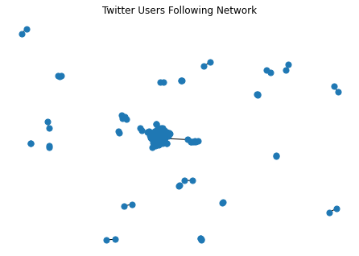

```python
pos = nx.spring_layout(G, seed=456233520)

# display the network
nx.draw(G, pos=pos, node_size=50)
plt.title("Twitter Users Following Network")
plt.show()
```

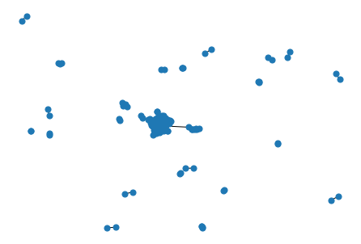

```python
nx.draw(G, pos=pos, node_size=50)
```

With the visualization of our network, we are able to see there is one major cluster of users who follow each other with smaller clusters with fewer connections on the outside. These visible clusters are the reason we decided to use KMeans clustering as it scales well with larger datasets, we are using numerical data, and it is efficient. One disadvantage to KMeans is the necessity to choose the number of clusters (k), however, we tackle this issue when performing KMeans.

One issue with this visualization, however, is we are unable to identify the influential users. This can be fixes by drawing these networks separately.

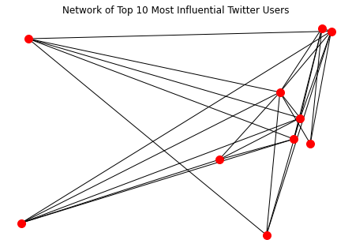

```python
# craete the positions and edges for the important nodes
ind_pos = dict()
for ind in inds:
    ind_pos[ind] = pos[ind]
ind_edges = []
for edge in G.edges():
    if edge[0] in inds and edge[1] in inds:
        ind_edges.append(edge)

# draw important nodes
nx.draw(G, nodelist=inds, edgelist=ind_edges, pos=ind_pos, node_size=100, node_color="red")
plt.title("Network of Top 10 Most Influential Twitter Users")
plt.show()
```

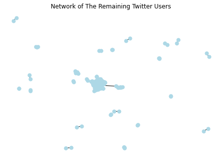

```python
# find positions, nodes, and edges of all other twitter users
nind_pos = dict()
for key in pos:
    if key not in ind_pos:
        nind_pos[key] = pos[key]
nind_nodes = []
for node in G.nodes():
    if node not in inds:
        nind_nodes.append(node)
nind_edges = []
for edge in G.edges():
    if edge[0] not in inds and edge[1] not in inds:
        nind_edges.append(edge)

# draw the other nodes
nx.draw(G, nodelist=nind_nodes, edgelist=nind_edges, pos=nind_pos, node_size=50, node_color="lightblue")
plt.title("Network of The Remaining Twitter Users")
plt.show()
```

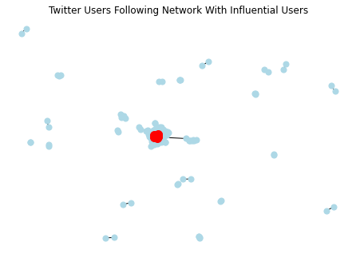

```python
# draw the influential nodes on top of the remaining nodes
nx.draw(G, nodelist=nind_nodes, edgelist=nind_edges, pos=nind_pos, node_size=50, node_color="lightblue")
nx.draw(G, nodelist=inds, edgelist=ind_edges, pos=ind_pos, node_size=100, node_color="red")
plt.title("Twitter Users Following Network With Influential Users")
plt.show()
```

With this updated visualization of our network, we can see the influential users are tightly clumped into the center cluster.

## KMeans

### Perform KMeans clustering

Due to the visible clusters in our network, we are using KMeans clustering to identify these. The problem, however, lies in how many clusters we choose to use (k). To start, we will use some a variety of values for k.

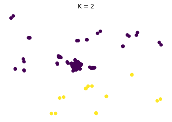

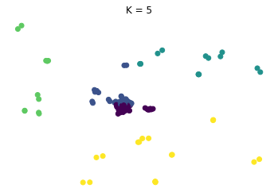

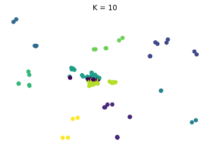

```python
# find node coordinates
node_coords = []
for key in pos:
    node = pos[key]
    node_coords.append([node[0], node[1]])
node_coords = np.array(node_coords)

# Calc KMeans with different values of k
sil_scores = []

# k = 2
mod = KMeans(n_clusters = 2).fit(node_coords)
sil_scores.append(silhouette_score(node_coords, mod.labels_))
plt.scatter(node_coords[:,0], node_coords[:,1], c=mod.labels_)
plt.title("K = 2")
plt.axis("off")
plt.show()

# k = 5
mod = KMeans(n_clusters = 5).fit(node_coords)
sil_scores.append(silhouette_score(node_coords, mod.labels_))
plt.scatter(node_coords[:,0], node_coords[:,1], c=mod.labels_)
plt.title("K = 5")
plt.axis("off")
plt.show()

# k = 10
mod = KMeans(n_clusters = 10).fit(node_coords)
sil_scores.append(silhouette_score(node_coords, mod.labels_))
plt.scatter(node_coords[:,0], node_coords[:,1], c=mod.labels_)
plt.title("K = 10")
plt.axis("off")
plt.show()
```

Just from looking at the three values, we can see 10 clusters is way too many and the sweet spot for the number of clusters we want is somewhere between 2 and 5. We can reinforce this by looking at a graph of the mean Silhouette scores) for each model. The Silhouette score is a measure of cluster "goodness." A value closer to 1 means the clusters are dense and well-separated while a value closer to 0 means there is overlap with the clusters. Additionally, a value which drops into the negative could indicate points being represented by incorrect clusters.

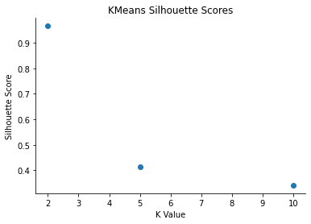

```python
ax = plt.subplot(111) # create subplot for axis manip
plt.scatter([2,5,10], sil_scores)
# set labels
plt.xlabel("K Value")
plt.ylabel("Silhouette Score")
plt.title("KMeans Silhouette Scores")
# turn off right and top axis
ax.spines['right'].set_visible(False)
ax.spines['top'].set_visible(False)

plt.show()
```

These Silhouette scores reinforce what we saw with the clusters. To further grasp possible values of K, we can plot Silhouette scores for values of K from 2 to 10.

```
[0.9662962250569153, 0.966069871988294, 0.966977345421462, 0.412501185885424, 0.4138345318001894, 0.41533529292806365, 0.4166023693309883, 0.34000699563242787, 0.339609997071166]
```

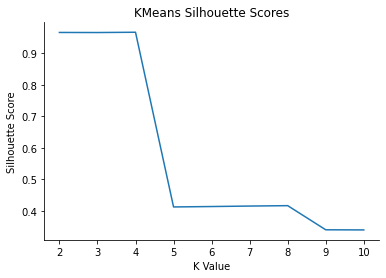

```python
# find Silhouette scores
sil_scores = []
for i in range(2,11):
    mod = KMeans(n_clusters = i).fit(node_coords)
    sil_scores.append(silhouette_score(node_coords, mod.labels_))
print(sil_scores)

# plot scores
ax = plt.subplot(111) # create subplot for axis manip
plt.plot([i for i in range(2,11)], sil_scores)
# set labels
plt.xlabel("K Value")
plt.ylabel("Silhouette Score")
plt.title("KMeans Silhouette Scores")
# turn off right and top axis
ax.spines['right'].set_visible(False)
ax.spines['top'].set_visible(False)

plt.show()
```

From this graph we can see a major decrease in cluster quality past 4 groups. Therefore, using this graph along with intuition from seeing the network, we will use K=4 for our model (which produces a Silhouette score of ~0.9668).

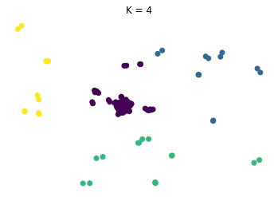

```python
mod = KMeans(n_clusters = 4).fit(node_coords)
plt.scatter(node_coords[:,0], node_coords[:,1], c=mod.labels_)
plt.title("K = 4")
plt.axis("off")
plt.show()
```

### Use clusters for analysis

Now that we have information about our clusters, we can begin to ask questions regarding these groupings. For example, does the data suggest the mean number of fake articles vary across the clusters? We can answer this question by using a 1-way ANOVA F-test.

```python
# add clusters to the dataframe to allow for grouping by cluster
cluster_df = pd.DataFrame({"user_id":range(1,len(mod.labels_)+1), "clusters":(mod.labels_+1)})
main_df = main_df.merge(cluster_df, on="user_id")
main_df.head()
```

|  | news_id | user_id | times_shared | news_name | isFake | clusters |
| --- | --- | --- | --- | --- | --- | --- |
| 0 | 45 | 1 | 1 | BuzzFeed_Real_46 | False | 1 |
| 1 | 127 | 2 | 1 | BuzzFeed_Fake_37 | True | 1 |
| 2 | 115 | 3 | 1 | BuzzFeed_Fake_25 | True | 1 |
| 3 | 180 | 3 | 1 | BuzzFeed_Fake_90 | True | 1 |
| 4 | 140 | 4 | 1 | BuzzFeed_Fake_50 | True | 1 |

$H_0: \mu_1=\mu_2=\mu_3=\mu_4$  
$H_1:$ At least one of the true means is different.

Where $\mu_k$ is the true mean number of articles shared by cluster k.

$\alpha=0.05$

```python
fake_articles_df = main_df[main_df.isFake==True]
_,pval = stats.f_oneway(fake_articles_df[fake_articles_df.clusters==1].times_shared,
                        fake_articles_df[fake_articles_df.clusters==2].times_shared,
                        fake_articles_df[fake_articles_df.clusters==3].times_shared,
                        fake_articles_df[fake_articles_df.clusters==4].times_shared)
print("p-value:",pval)
```

```
p-value: 0.8370971949099597
```

Due to our p-value (~0.8371) being larger than our $\alpha=0.05$, we do not reject our $H_0$ in favor of $H_1$. Therefore, there is no support from the data that the mean number of fake news articles differs from cluster to cluster.

## Pros And Cons to This Model

Some potential benefits to this model are its capabilities for usage in future analysis. For example, the clusters found from this network could be paired with an analysis of the specific articles shared to attempt to predict where a user would be placed in the network. Another possibility would be to use the clusters to attempt to predict how much misinformation or information in general is shared through a specific user.

There are some harms this model could produce, however, that we should be wary of. The major problem stems from what actions companies may take if they used a model was to identify a group more likely to spread misinformation. Should they leave these users be, limit the amount of people who see their posts, or ban them from the platform altogether? These are all scenarios which could be viewed as negative depending on one's beliefs which need to be considered when applying a model such as this one. Another issue with this model is its lack of awareness of its biases. No information was provided about the specific groups of people this data was scraped from, therefore, it is hard to justify any statements made from this model as it could only be effective on a specific subset of people.

This model/analysis opens up many questions for future research. One of these is, through the use of Twitter's API, could we predict influential users based on the posts they make or could we find similarities between clusters. These are interseting questions as they could further refine our network and may expose a consistency with the spread of misinformation.